# London Bike Journeys - August 2023

Exploratory Data Analysis

Doniyor

March 2026

## Introduction

This report explores **776,527 bike journeys** recorded across London during **August 2023**, using data from the Santander Cycles (TfL) scheme. August represents one of the busiest months for cycling in London due to warmer weather and tourist activity.

The analysis focuses on three key areas:

- **Trip Duration & Patterns** — How long are journeys, and do they vary by day?
- **Most Popular Stations** — Which docking stations see the highest demand?
- **Peak Hours** — When during the day and week are bikes used most?

## Trip Duration & Patterns

Understanding how long people cycle helps reveal the purpose of journeys — short trips under 10 minutes likely reflect commutes or quick errands, while longer trips may indicate leisure rides, especially on weekends.

The histogram below shows the distribution of all trip durations in August 2023. Trips longer than 60 minutes have been excluded from the chart for clarity, though they are included in all calculations.

| Metric | Minutes |
| --- | --- |
| Minimum | 0.02 |
| Median | 13.90 |
| Mean | 18.60 |
| Maximum | 180.00 |

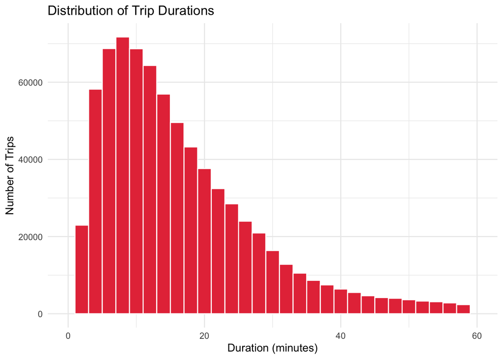

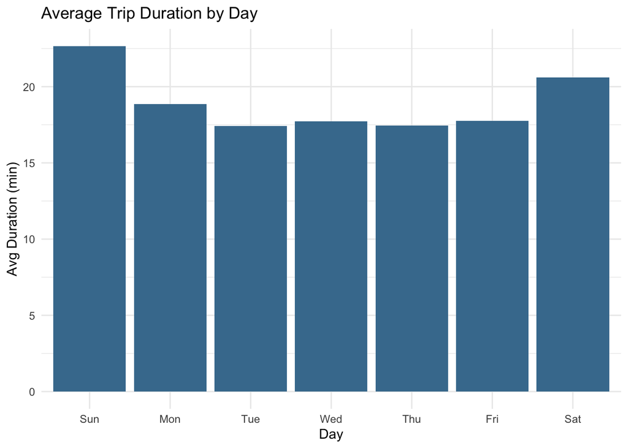

The bar chart above shows how average trip duration varies across days of the week. Weekend trips (Saturday and Sunday) tend to be longer on average, suggesting cyclists use the bikes more leisurely rather than for commuting purposes.

## Most Popular Stations

With hundreds of docking stations spread across London, demand is not evenly distributed. Stations near transport hubs, tourist attractions, and the City of London financial district tend to see significantly higher usage.

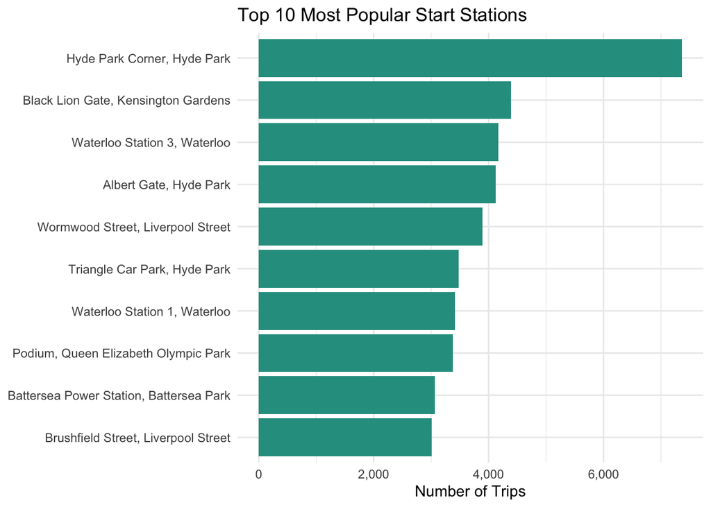

| Station | Trips |
| --- | --- |
| Hyde Park Corner, Hyde Park | 7376 |
| Waterloo Station 3, Waterloo | 4624 |
| Black Lion Gate, Kensington Gardens | 4396 |
| Albert Gate, Hyde Park | 4146 |
| Brushfield Street, Liverpool Street | 4047 |
| Hop Exchange, The Borough | 3907 |
| Wormwood Street, Liverpool Street | 3894 |
| Triangle Car Park, Hyde Park | 3487 |
| Waterloo Station 1, Waterloo | 3469 |
| Podium, Queen Elizabeth Olympic Park | 3468 |

The table above lists the top 10 most popular **end stations**. Comparing start and end station rankings can reveal interesting directional patterns — for example, whether certain stations are primarily origins (commuters leaving home) or destinations (commuters arriving at work).

## Peak Hours Analysis

Identifying when bikes are used most heavily is crucial for managing bike availability and dock capacity. London’s cycling patterns typically reflect its working population, with clear spikes during morning and evening rush hours on weekdays.

The line chart below shows total trips per hour across all of August 2023. Two distinct peaks are visible — one in the **morning (8–9am)** and one in the **evening (5–6pm)** — consistent with typical commuter behaviour.

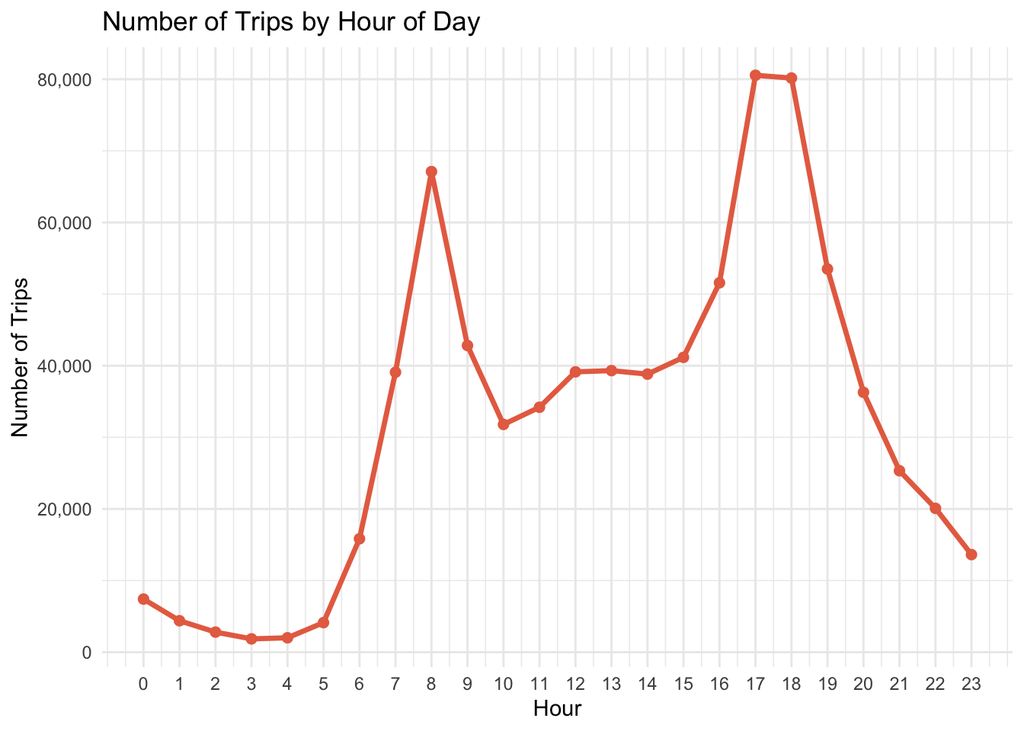

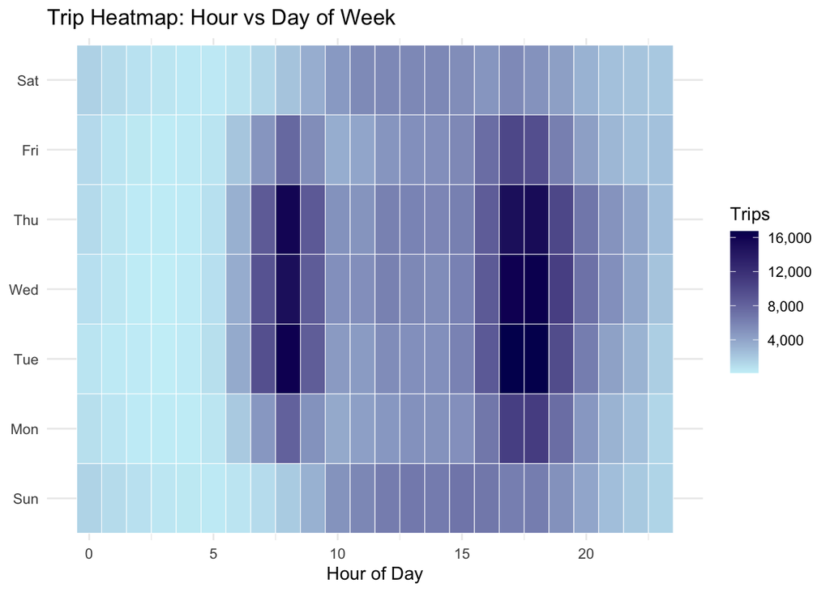

The heatmap above combines hour of day with day of week, revealing a more complete picture of usage patterns. Weekday mornings and evenings show the deepest colour, confirming commuter-driven demand. Weekends show a different pattern — activity spreads more evenly through midday hours rather than peaking at rush hour times.

## Conclusion

This analysis of London’s Santander Cycles data for August 2023 reveals several clear patterns:

- The **median trip duration is approximately 14 minutes**, with weekend journeys averaging longer than weekday ones — suggesting a shift from commuting to leisure use.
- A small number of **central London stations dominate demand**, particularly those near major transport hubs and tourist areas.
- Usage follows a clear **double-peak pattern on weekdays** (8–9am and 5–6pm), while weekends show a flatter, midday-centred distribution.

These insights could help TfL optimise **bike redistribution**, prioritise **dock maintenance**, and plan **capacity during peak periods**.